# RDD on unemployment entry sample

Author

Elisa Alonso Herrero

Published

May 26, 2026

# 1. Create the RD entry-into-unemployment sample

**Reform recap**: The Feb 2012 reform gave employers with less than 50 workers a payroll-tax reduction for hiring **unemployed workers aged below 31** on an OE contract. The RDD exploits the sharp age-31 cutoff: workers who entered unemployment just below vs. just above age 31 during the first year of the reform.

**Sample construction:**

1. **Identify entrants** (Step 1): scan the panel for workers aged 26-35 who entered unemployment during the first year post-reform window [201203, 201303], from `source_wave > 2016` (fully observed through 2016).
2. **Load their full panel** (Step 2): window [201102, 201703] one month before the entry window (so the prev-month lag at the first entry is observed) through 48 months after the last possible entry (201303 + 48m = 201703).

## 1.1 Identify entrants

Unemployment (UA + STU + LTU): There are 116,059 entry events among workers aged 26-35 in the first year post reform. If we look at unique individuals, 49,998 people entered into “unemployment” aged 26-35 in the first year post-reform. Restricting to 27-34 instead we get 39,519 workers

Unemployment assistance (UA) only: There are 107,320 events of entering UA among workers aged 26-35 in the first year post reform, corresponding to 42,805 unique individuals.

```r
# Step 1: Build entry tables for both definitions in one Arrow scan.
# Results: RDD_unemp_entries (UA+LTU+STU) and RDD_ua_entries (registered UI only).
# all_entries_RDD: points to the active definition (RDD_ENTRY_COL) for downstream chunks.

.wave_lookup <- arrow::read_parquet(
  file.path(PATHS$mcvl$clean, "mcvl_wave_lookup.parquet"),
  col_select = c("id", "source_wave")
) %>% data.table::as.data.table()
.keep_ids_wave <- .wave_lookup[source_wave >= RDD_SOURCE_WAVE, id]
rm(.wave_lookup)
cat(sprintf("Workers in source_wave >= %d: %s\n",
            RDD_SOURCE_WAVE, format(length(.keep_ids_wave), big.mark = ",")))

.raw <- arrow::open_dataset(
  file.path(PATHS$mcvl$clean, "id_ym_cc1_corrected_enriched.parquet")
) %>%
  dplyr::filter(
    id %in% .keep_ids_wave,
    ym >= RDD_ENTRY_LO & ym <= RDD_ENTRY_HI,
    (unemp_entry_d == 1L | ua_entry_d == 1L),
    age_frac >= RDD_AGE_LO & age_frac < RDD_AGE_HI
  ) %>%
  dplyr::select(id, ym, unemp_entry_d, ua_entry_d, age_frac) %>%
  dplyr::arrange(id, ym) %>%
  dplyr::collect() %>%
  data.table::as.data.table()
rm(.keep_ids_wave)

data.table::setnames(.raw, "ym", "entry_ym")
data.table::setorderv(.raw, c("id", "entry_ym"))

# Create RDD entries dataset: one row per entry evennt, with flags for first entry per worker.
for (.col in c("unemp_entry_d", "ua_entry_d")) {
  .out <- .raw[get(.col) == 1L, .(id, entry_ym, age_frac)]
  .out[, n_entries := .N, by = id] # How many entries per worker? (diagnostic)
  .out[, .row := .I]
  .out[, (.col) := 1L]
  mark_first(.out, "first_entry_d", .col, by_cols = "id")
  .out[, c(".row", .col) := NULL]
  .nm <- if (.col == "unemp_entry_d") "rdd_unemp_entries" else "rdd_ua_entries"
  assign(.nm, .out)
  cat(sprintf("%-20s %s events  |  %s workers\n", paste0(.nm, ":"),
    format(nrow(.out),         big.mark = ","),
    format(uniqueN(.out$id),   big.mark = ",")))
}
rm(.raw, .out, .col, .nm)

rdd_entries <- switch(RDD_ENTRY_COL,
  unemp_entry_d = rdd_unemp_entries,
  ua_entry_d    = rdd_ua_entries
)
```

### Check: do we lose a lot of events by restricting to source_wave >= 2017?

No. With source wave > 2017 we have 49,998 unique workers entering unemployment, compared to 50,531 workers for source wave >= 2016 and 54,429 workers with no source wave filter.

```r
# Diagnostic: how does the source_wave filter affect sample size?
# Compares no filter, wave >= 2016, and wave >= 2017 (current spec).
# Does not modify all_entries_RDD  reads the parquet directly.

.wave_lookup <- arrow::read_parquet(
  file.path(PATHS$mcvl$clean, "mcvl_wave_lookup.parquet"),
  col_select = c("id", "source_wave")
) %>% data.table::as.data.table()

.candidates <- arrow::open_dataset(
  file.path(PATHS$mcvl$clean, "id_ym_cc1_corrected_enriched.parquet")
) %>%
  dplyr::filter(
    ym >= RDD_ENTRY_LO & ym <= RDD_ENTRY_HI,
    .data[[RDD_ENTRY_COL]] == 1L,
    age_frac >= RDD_AGE_LO & age_frac < RDD_AGE_HI
  ) %>%
  dplyr::select(id, ym) %>%
  dplyr::collect() %>%
  data.table::as.data.table()

.candidates[.wave_lookup, on = "id", source_wave := i.source_wave]
rm(.wave_lookup)

.scenarios <- list(
  "no filter"       = .candidates[,                           unique(id)],
  "wave >= 2016"    = .candidates[source_wave >= 2016L,       unique(id)],
  "wave >= 2017"    = .candidates[source_wave >= 2017L,       unique(id)]  # current spec
)

cat("Source-wave filter sensitivity:\n")
for (.nm in names(.scenarios))
  cat(sprintf("  %-16s %s workers\n", .nm, format(length(.scenarios[[.nm]]), big.mark = ",")))

rm(.candidates, .scenarios)
```

### Check: how many entries do we have per person?

```r
# Distribution of number of entry events per worker (diagnostic: do we have many repeaters?)
rdd_entries[first_entry_d == 1L, .N, by = n_entries][order(n_entries)]
```

```
    n_entries     N
        <int> <int>
 1:         1 18785
 2:         2 10439
 3:         3  3553
 4:         4  2165
 5:         5  1349
 6:         6   853
 7:         7   845
 8:         8   554
 9:         9   375
10:        10   228
11:        11   142
12:        12   103
13:        13   128
```

## 1.2 Build RDD sample

### Step 1: Create RDD base sample

The base sample will be the first time a person enters unemployment in the entry window, and we assign their age (in months) at that first entry as the running variable.

```r
# One row per worker at their first entry: id, ref_entry_ym, age_frac, age_centered, n_entries.
# Built first so rdd_sample$id drives the panel filter below.
rdd_sample <- rdd_entries[first_entry_d == 1L,
                          .(id, ref_entry_ym = entry_ym, age_frac, n_entries)]
rdd_sample[, age_centered := age_frac - RDD_CUTOFF]
cat(sprintf("RDD sample (before disability filter): %s workers\n",
            format(nrow(rdd_sample), big.mark = ",")))

# Drop workers ever recorded with a positive disability degree over the panel window.
# Disabled workers qualify for separate bonification programs using the same contract
# codes (109/150) regardless of age, which would contaminate the take-up measure.
.disabil_ids <- arrow::open_dataset(
  file.path(PATHS$mcvl$clean, "id_ym_cc1_corrected_enriched.parquet")
) %>%
  dplyr::filter(
    id %in% rdd_sample$id,
    ym >= RDD_PANEL_LO & ym <= RDD_PANEL_HI,
    disabil_deg >= 33L
  ) %>%
  dplyr::select(id) %>%
  dplyr::distinct() %>%
  dplyr::collect() %>%
  data.table::as.data.table()

rdd_sample <- rdd_sample[!id %in% .disabil_ids$id]
cat(sprintf("Dropped (ever disabled): %s workers\n",
            format(nrow(.disabil_ids), big.mark = ",")))
cat(sprintf("RDD sample (after disability filter): %s workers\n",
            format(nrow(rdd_sample), big.mark = ",")))
rm(.disabil_ids)
```

### Step 2: Load the full panel for the base sample and join with contributions

Loads the full monthly panel for those workers over the period 201102-201703. This is needed to pull up the outcomes and build the covariates. Now in this step, we also load contributions to assign wages

```r
# Panel for rdd_sample workers only, over the full outcome window.
# ref_entry_ym joined in from rdd_sample so covariates chunk can filter by entry month.
panel_raw <- arrow::open_dataset(
  file.path(PATHS$mcvl$clean, "id_ym_cc1_corrected_enriched.parquet")
) %>%
  dplyr::filter(ym >= RDD_PANEL_LO & ym <= RDD_PANEL_HI & id %in% rdd_sample$id) %>%
  dplyr::select(
    id, ym, cc2_id,
    f_main_job, inactive_d, UA_d, unemp_d,
    female_d, education_cat, exp_days,
    overlap_days, pt_coef, working_hours_160,
    cont_regime_cat, cont_group,
    unemp_exit_to_work_d, unemp_exit_to_oe_d, unemp_exit_to_temp_d,
    dplyr::any_of(RDD_OUTCOMES)
  ) %>%
  dplyr::collect() %>%
  data.table::as.data.table()

panel_raw[rdd_sample, on = "id", ref_entry_ym := i.ref_entry_ym]
setorderv(panel_raw, c("id", "ym"))

cat(sprintf(
  "Panel loaded: %s rows  |  %s workers\n",
  format(nrow(panel_raw), big.mark = ","),
  format(uniqueN(panel_raw$id), big.mark = ",")
))
```

```r
# Load contributions (GENERAL REGIME only  special regime rows get no wage)
contr <- arrow::open_dataset(
  file.path(PATHS$mcvl$clean, "mcvl_contribution_general_long.parquet")
) %>%
  dplyr::filter(ym >= RDD_PANEL_LO & ym <= RDD_PANEL_HI & id %in% rdd_sample$id) %>%
  dplyr::collect() %>%
  data.table::as.data.table()

data.table::setkeyv(panel_raw, c("id", "ym", "cc2_id"))
data.table::setkeyv(contr, c("id", "ym", "cc2_id"))

panel_raw[contr, on = .(id, ym, cc2_id), cont_base_ym := i.cont_base_ym]

# Sanity check: missingness of cont_base_ym by employment status
.check <- panel_raw[, .(
  n_total              = .N,
  n_missing_cont       = sum(is.na(cont_base_ym)),
  n_missing_cont_work  = sum(is.na(cont_base_ym) & work_d  == 1L, na.rm = TRUE),
  n_missing_cont_ua    = sum(is.na(cont_base_ym) & UA_d    == 1L, na.rm = TRUE)
)]
cat(sprintf(paste(
  "[CHECK] cont_base_ym missingness:",
  "%s total rows | %s missing overall | %s missing when work_d==1 | %s missing when UA_d==1\n"
),
  format(.check$n_total,             big.mark = ","),
  format(.check$n_missing_cont,      big.mark = ","),
  format(.check$n_missing_cont_work, big.mark = ","),
  format(.check$n_missing_cont_ua,   big.mark = ",")
))

rm(contr, .check)
```

```r
## ---- Wage construction ----------------------------------------------------
# dim: calendar days in the month
panel_raw[, dim := data.table::fcase(
  ym %% 100L %in% c(1L, 3L, 5L, 7L, 8L, 10L, 12L), 31L,
  ym %% 100L %in% c(4L, 6L, 9L, 11L),               30L,
  ym == 201202L,                                     29L,   # Feb 2012 leap year
  default =                                          28L
)]

# Actual hours worked: FT equivalent (160h/month)— pt_coef— fraction of month active.
# overlap_days / dim prorates for partial months (e.g. spell started mid-month).
panel_raw[, actual_hours := pt_coef * 160 * (overlap_days / dim)]

# Hourly wage: cont_base_ym reflects earnings for the active days only, so dividing
# by actual hours gives the true hourly rate.
panel_raw[, cont_base_hourly := fifelse(
  !is.na(actual_hours) & actual_hours > 0,
  cont_base_ym / actual_hours,
  NA_real_
)]

# Monthly FTE wage: what a full-timer at the same hourly rate would earn in a full month.
panel_raw[, cont_base_monthly_fte := cont_base_hourly * 160]

print(panel_raw[, .(
  cont_base_ym          = mean(cont_base_ym,          na.rm = TRUE),
  cont_base_hourly      = mean(cont_base_hourly,      na.rm = TRUE),
  cont_base_monthly_fte = mean(cont_base_monthly_fte, na.rm = TRUE)
)])
```

```r
## ---- Censoring check -------------------------------------------------------
# Load SSC contribution caps (monthly min/max by year x cont_group)
caps_ssc <- readxl::read_excel(
  file.path(PATHS$mcvl$raw, "spain_ssc_bases_cotizacion_2000_2024.xlsx"),
  sheet = "Bases"
) %>%
  data.table::as.data.table() %>%
  data.table::setnames(
    c("Year", "Contribution Group", "Min Base (€/month)", "Max Base (€/month)", "Source"),
    c("year",  "cont_group",         "base_min_ssc",        "base_max_ssc",        "source_ref")
  ) %>%
  .[, year := as.integer(year)] %>%
  .[, cont_group := as.integer(cont_group)]

panel_raw[, year := ym %/% 100L]

panel_raw[caps_ssc[, .(year, cont_group, base_min_ssc, base_max_ssc)],
          on = .(year, cont_group),
          `:=`(base_min = i.base_min_ssc,
               base_max = i.base_max_ssc)]

# Compare FTE monthly wage against monthly caps.
# cont_base_monthly_fte = cont_base_hourly * 160 = what a full-timer at the same
# hourly rate would earn  this is the right quantity to compare against the SSC caps,
# which are defined on a FTE basis.
# Exclude cont_base_ym == 0: observed zeros (no wage that month), not censored wages.
panel_raw[, f_top_coded    := as.integer(
  cont_base_ym > 0 & !is.na(cont_base_monthly_fte) & !is.na(base_max) &
  cont_base_monthly_fte >= base_max * 0.99
)]
panel_raw[, f_bottom_coded := as.integer(
  cont_base_ym > 0 & !is.na(cont_base_monthly_fte) & !is.na(base_min) &
  cont_base_monthly_fte <= base_min * 1.01
)]

rm(caps_ssc)
```

### Step 3: Prepare outcomes

We need only one row per worker so we need to create a column for each outcome. Since we are also going to look at outcomes over a 48-month horizon, we need to create one column per outcome— horizon: work_d_m0, work_d_m1, ¦ contract_oe_d_m48.

```r
#  Step 1: panel spine
# Rows where the worker was in a main job or inactive  the lookup table for all joins.
.spine <- panel_raw[
  f_main_job == TRUE | inactive_d == 1L,
  c("id", "ym", RDD_OUTCOMES), with = FALSE
]

#  Step 2: expand to (worker— horizon)
# Every worker gets one row per horizon (0¦48), with target_ym = ref_entry_ym + horizon.
# This is the grid we will join outcome values onto.
.n  <- nrow(rdd_sample)
.nh <- length(RDD_HORIZONS)
.targets <- data.table::data.table(
  id           = rep(rdd_sample$id,           each = .nh),
  ref_entry_ym = rep(rdd_sample$ref_entry_ym, each = .nh),
  horizon      = rep(RDD_HORIZONS,            times = .n)
)
.targets[, target_ym := add_months_ym(ref_entry_ym, horizon)]
rm(.n, .nh)

#  Step 3: single join
# Match each (worker, target_ym) to the spine. Unmatched rows stay NA (worker
# not observed that month). One join replaces length(RDD_HORIZONS)— n_outcomes joins.
for (.oc in RDD_OUTCOMES) {
  .targets[.spine, on = .(id, target_ym = ym),
           paste0("v_", .oc) := get(paste0("i.", .oc))]
}

#  Step 4: pivot wide
# Zero-pad horizons (m00, m01¦) so lexicographic sort = numeric sort, then dcast.
# One column per outcome— horizon: work_d_m0, work_d_m1, ¦ contract_oe_d_m48, ¦
.targets[, h_label := sprintf("m%02d", horizon)]
.wide <- data.table::dcast(
  .targets,
  id ~ h_label,
  value.var = paste0("v_", RDD_OUTCOMES),
  sep = "_"
)
data.table::setnames(.wide, function(n) sub("^v_", "", n))          # v_work_d_m00  work_d_m00
data.table::setnames(.wide, function(n) gsub("_m0*(\\d+)$", "_m\\1", n))  # m00  m0, m01  m1

.new_cols <- setdiff(names(.wide), "id")
rdd_sample[.wide, on = "id", (.new_cols) := mget(paste0("i.", .new_cols))]
rm(.targets, .wide, .spine, .new_cols)

#  Step 5: derived outcomes
# cum_work_m{h}: cumulative months employed from m1 through mH (m0 excluded
# we condition on having entered unemployment, so the entry month is not counted).
# Max value of cum_work_m{h} = h (not h+1).
.work_cols <- paste0("work_d_m", RDD_HORIZONS)
for (.h in RDD_HORIZONS) {
  .cols <- .work_cols[seq_len(.h + 1L)]
  .cols <- .cols[.cols != "work_d_m0"]          # drop entry month
  if (length(.cols) == 0L) {
    rdd_sample[, paste0("cum_work_m", .h) := 0L]
  } else {
    rdd_sample[, paste0("cum_work_m", .h) :=
      rowSums(.SD, na.rm = TRUE), .SDcols = .cols]
  }
}
rm(.work_cols)

# cum_employee_priv_oe_m{h}: cumulative months in private OE from m1 through mH.
.priv_oe_cols <- paste0("employee_priv_oe_d_m", RDD_HORIZONS)
for (.h in RDD_HORIZONS) {
  .cols <- .priv_oe_cols[seq_len(.h + 1L)]
  .cols <- .cols[.cols != "employee_priv_oe_d_m0"]
  if (length(.cols) == 0L) {
    rdd_sample[, paste0("cum_employee_priv_oe_m", .h) := 0L]
  } else {
    rdd_sample[, paste0("cum_employee_priv_oe_m", .h) :=
      rowSums(.SD, na.rm = TRUE), .SDcols = .cols]
  }
}
rm(.priv_oe_cols)

# within_12m_{outcome}: 1 if outcome == 1 in any month m0-m12.
# NA only when the worker has no observed rows at all in that window.
# pmax(..., na.rm=TRUE) across columns is vectorised; -Inf (all-NA result)  NA.
for (.oc in RDD_OUTCOMES) {
  .cols <- intersect(paste0(.oc, "_m", 0:12), names(rdd_sample))
  if (length(.cols) == 0L) next
  rdd_sample[, paste0("within_12m_", .oc) := {
    .m <- do.call(pmax, c(lapply(.cols, function(v) get(v)), list(na.rm = TRUE)))
    .m[is.infinite(.m)] <- NA_real_
    .m
  }]
}
```

```r
# ---- Conditional-on-private-employment outcomes ------------------------------
# All variables here are NA when not in private sector that month, so they
# measure outcomes conditional on employment — separate from the employment margin.
# Built outside RDD_OUTCOMES because the conditioning doesn't exist in the panel.
#
# Variables built:
#   wage_priv_m{h}:              FTE monthly wage (cont_base_monthly_fte | priv employed)
#   f_top_m{h} / f_bot_m{h}:    top/bottom censoring flags (| priv employed)
#   takeup_priv_m{h}:            contract_potential_d | priv employed (subsidy take-up proxy)
#   f_ever_top_m12 / _bot_m12:   ever censored in m1-m12
#   mean_wage_priv_m12:          mean wage over m1-m12 (NA months = not employed, excluded)
#   mean_wage_priv_m12_uncensored: same, NA for workers ever censored
#   within_12m_takeup_priv:      1 if took up bonified OE contract in any m1-m12 month

stopifnot("employee_priv_d"      %in% names(panel_raw),
          "cont_base_monthly_fte" %in% names(panel_raw),
          "f_top_coded"           %in% names(panel_raw),
          "contract_potential_d"  %in% names(panel_raw))

# --- Step A: build spine (one row per main-job month in private employment) ---
# Wage/censoring require a non-missing cont_base_monthly_fte.
# Take-up (contract_potential_d) only requires being in private employment —
# requiring a wage would incorrectly drop bonified months with missing contributions.
.wage_spine <- panel_raw[
  f_main_job == TRUE & employee_priv_d == 1L,
  .(id, ym,
    wage_priv   = fifelse(!is.na(cont_base_monthly_fte), cont_base_monthly_fte, NA_real_),
    f_top       = fifelse(!is.na(cont_base_monthly_fte), f_top_coded,           NA_integer_),
    f_bot       = fifelse(!is.na(cont_base_monthly_fte), f_bottom_coded,        NA_integer_),
    takeup_priv = contract_potential_d)
]

# --- Step B: expand to (worker × horizon) grid and join -----------------------
.n  <- nrow(rdd_sample)
.nh <- length(RDD_HORIZONS)
.wage_targets <- data.table::data.table(
  id           = rep(rdd_sample$id,                        each = .nh),
  ref_entry_ym = rep(as.integer(rdd_sample$ref_entry_ym), each = .nh),
  horizon      = rep(RDD_HORIZONS,                         times = .n)
)
.wage_targets[, target_ym := add_months_ym(ref_entry_ym, horizon)]
# Ensure ym and target_ym are both integer before joining
.wage_spine[, ym := as.integer(ym)]
.wage_targets[, target_ym := as.integer(target_ym)]
.wage_targets[.wage_spine, on = .(id, target_ym = ym),
              `:=`(v_wage_priv   = i.wage_priv,
                   v_f_top       = i.f_top,
                   v_f_bot       = i.f_bot,
                   v_takeup_priv = i.takeup_priv)]
# Unmatched rows stay NA: worker either not observed or not in private employment that month.

# --- Step C: pivot wide and attach to rdd_sample ------------------------------
# dcast all value vars at once so column names are prefixed (e.g. wage_priv_m1, takeup_priv_m1).
# Single-value dcast drops the value.var name from headers — multi-value preserves it.
.wage_targets[, h_label := sprintf("m%02d", horizon)]
.w <- data.table::dcast(
  .wage_targets, id ~ h_label,
  value.var = c("v_wage_priv", "v_f_top", "v_f_bot", "v_takeup_priv"),
  sep = "_"
)
# Rename: v_wage_priv_m00 → wage_priv_m00 → wage_priv_m0
data.table::setnames(.w, function(n) sub("^v_", "", n))
data.table::setnames(.w, function(n) gsub("_m0*(\\d+)$", "_m\\1", n))
.nc <- setdiff(names(.w), "id")
rdd_sample[.w, on = "id", (.nc) := mget(paste0("i.", .nc))]
rm(.w, .nc)
rm(.wage_spine, .wage_targets, .n, .nh)

# --- Step D: year-1 aggregates ------------------------------------------------
.wcols  <- intersect(paste0("wage_priv_m",   1:12), names(rdd_sample))
.tcols  <- intersect(paste0("f_top_m",       1:12), names(rdd_sample))
.bcols  <- intersect(paste0("f_bot_m",       1:12), names(rdd_sample))
.tucols <- intersect(paste0("takeup_priv_m", 1:12), names(rdd_sample))

# Ever top/bottom censored in m1-m12 (among observed private-employment months).
rdd_sample[, f_ever_top_m12 := {
  .m <- do.call(pmax, c(lapply(.tcols, function(v) get(v)), list(na.rm = TRUE)))
  .m[is.infinite(.m)] <- NA_real_
  .m
}]
rdd_sample[, f_ever_bot_m12 := {
  .m <- do.call(pmax, c(lapply(.bcols, function(v) get(v)), list(na.rm = TRUE)))
  .m[is.infinite(.m)] <- NA_real_
  .m
}]

# mean_wage_priv_m12: mean FTE wage over m1-m12, averaging only employed months (NA if never in private sector)
rdd_sample[, mean_wage_priv_m12 := {
  .m <- rowMeans(.SD, na.rm = TRUE)
  .m[is.nan(.m)] <- NA_real_
  .m
}, .SDcols = .wcols]

# mean_wage_priv_m12_uncensored: NA for any worker ever top- or bottom-censored in m1-m12
rdd_sample[, mean_wage_priv_m12_uncensored := fifelse(
  !is.na(f_ever_top_m12) & f_ever_top_m12 == 1L, NA_real_,
  fifelse(!is.na(f_ever_bot_m12) & f_ever_bot_m12 == 1L, NA_real_,
          mean_wage_priv_m12)
)]

# within_12m_takeup_priv: 1 if had a bonified OE contract in any private-employment month
# in m1-m12. NA if never in private employment (so denominator = workers who found priv. work).
rdd_sample[, within_12m_takeup_priv := {
  .m <- do.call(pmax, c(lapply(.tucols, function(v) get(v)), list(na.rm = TRUE)))
  .m[is.infinite(.m)] <- NA_real_
  .m
}]

rm(.wcols, .tcols, .bcols, .tucols)

# --- Sanity checks ------------------------------------------------------------
# n non-NA in wage_priv_m1: workers in private employment at month 1
cat(sprintf("wage_priv_m1: n non-NA (in private employment at m1) = %s\n",
  format(sum(!is.na(rdd_sample$wage_priv_m1)), big.mark = ",")))
cat(sprintf("f_ever_top_m12: %s censored  |  f_ever_bot_m12: %s censored\n",
  format(sum(rdd_sample$f_ever_top_m12 == 1L, na.rm = TRUE), big.mark = ","),
  format(sum(rdd_sample$f_ever_bot_m12 == 1L, na.rm = TRUE), big.mark = ",")))
cat(sprintf("mean_wage_priv_m12:            n=%s  mean=%.1f\n",
  format(sum(!is.na(rdd_sample$mean_wage_priv_m12)),            big.mark = ","),
  mean(rdd_sample$mean_wage_priv_m12,            na.rm = TRUE)))
cat(sprintf("mean_wage_priv_m12_uncensored: n=%s  mean=%.1f\n",
  format(sum(!is.na(rdd_sample$mean_wage_priv_m12_uncensored)), big.mark = ","),
  mean(rdd_sample$mean_wage_priv_m12_uncensored, na.rm = TRUE)))
cat(sprintf("within_12m_takeup_priv: n non-NA=%s  mean=%.3f\n",
  format(sum(!is.na(rdd_sample$within_12m_takeup_priv)), big.mark = ","),
  mean(rdd_sample$within_12m_takeup_priv, na.rm = TRUE)))
```

### Step 4: Prepare covariates

```r
# All covariates are measured at ref_entry_ym (the entry month).
# To add a new covariate:
#   (a) if it exists in panel_raw at entry month: add its name to .COVS_AT_ENTRY below.
#   (b) if it needs computing from panel history: add a block below.
#   (c) if it comes from an external dataset (e.g. personal): load and join below.

.COVS_AT_ENTRY <- c("female_d", "education_cat", "exp_days", "UA_d")

.cov_entry <- panel_raw[ym == ref_entry_ym, c("id", "ym", .COVS_AT_ENTRY), with = FALSE]
rdd_sample[.cov_entry, on = .(id, ref_entry_ym = ym),
           (.COVS_AT_ENTRY) := mget(paste0("i.", .COVS_AT_ENTRY))]
rm(.cov_entry)

data.table::setnames(rdd_sample, "UA_d", "entry_ua_d")
rdd_sample[, entry_month := ref_entry_ym %% 100L]

# Fallback for time-invariant vars (female_d, education_cat): take first non-NA across all months.
for (.v in c("female_d", "education_cat")) {
  .miss_ids <- rdd_sample[is.na(get(.v)), id]
  if (length(.miss_ids) == 0L) next
  .fb <- panel_raw[id %in% .miss_ids & !is.na(get(.v)),
                   .(tmp_ = data.table::first(get(.v))), by = id]
  rdd_sample[.fb, on = "id", (.v) := i.tmp_]
  rm(.fb, .miss_ids)
}

# exp_days fallback: NA at entry = gap row (spell just ended, no active spell that month).
# Use the last non-NA exp_days strictly before entry  spell_start_exp already accumulates
# all history, so this is correct regardless of the panel window.
.miss_ids <- rdd_sample[is.na(exp_days), id]
if (length(.miss_ids) > 0L) {
  .fb <- panel_raw[id %in% .miss_ids & !is.na(exp_days) & ym < ref_entry_ym,
                   .(exp_days = data.table::last(exp_days)), by = id]
  rdd_sample[.fb, on = "id", exp_days := i.exp_days]
  rm(.fb)
}
cat(sprintf("exp_days still missing after fallback (true first-time entrants): %d\n",
            rdd_sample[is.na(exp_days), .N]))
rm(.miss_ids)

# Education dummies (ref: Primary or less = 1)
rdd_sample[, educ_primary_d   := as.integer(education_cat == 1L)]
rdd_sample[, educ_secondary_d := as.integer(education_cat == 2L)]
rdd_sample[, educ_tertiary_d  := as.integer(education_cat == 3L)]

# (b) History-derived covariates
# n_prior_ua_months: count UA months across full observable history, not just panel_raw
# window (panel_raw starts 201102  too short for older workers with earlier UA spells).
# Push the id filter into Arrow; collect only UA_d == 1 rows to minimise memory.
.max_entry_ym <- max(rdd_sample$ref_entry_ym)
.cov_ua <- arrow::open_dataset(
  file.path(PATHS$mcvl$clean, "id_ym_cc1_corrected_enriched.parquet")
) %>%
  dplyr::filter(id %in% rdd_sample$id, UA_d == 1L, ym < .max_entry_ym) %>%
  dplyr::select(id, ym) %>%
  dplyr::collect() %>%
  data.table::as.data.table()

# Filter ym < ref_entry_ym per worker after collect (Arrow can't reference rdd_sample columns)
.cov_ua[rdd_sample, on = "id", ref_entry_ym := i.ref_entry_ym]
.cov_ua <- .cov_ua[ym < ref_entry_ym, .(n_prior_ua_months = .N), by = id]
rdd_sample[.cov_ua, on = "id", n_prior_ua_months := i.n_prior_ua_months]
rdd_sample[is.na(n_prior_ua_months), n_prior_ua_months := 0L]
rm(.cov_ua, .max_entry_ym)

# (c) External dataset covariates
# birth_country from mcvl_personal; take most recent non-NA wave per worker.
.personal <- arrow::read_parquet(
  file.path(PATHS$mcvl$clean, "mcvl_personal.parquet"),
  col_select = c("id", "birth_country")
) %>%
  data.table::as.data.table() %>%
  .[!is.na(birth_country), .(birth_country = data.table::last(birth_country)), by = id]

rdd_sample[.personal, on = "id", birth_country := i.birth_country]
rm(.personal)

# Nationality dummies  fifelse preserves NA when birth_country is unknown
.eu_codes <- paste0("N", c("01", "04", "10", "11", "14", "15", "16", "17", "18", "19", "20"))
.la_codes  <- paste0("N", c("03", "06", "07", "08", "09", "13", "26", "27", "22"))
rdd_sample[, nat_spanish_d       := data.table::fifelse(is.na(birth_country), NA_integer_, as.integer(birth_country == "N00"))]
rdd_sample[, nat_eu_d            := data.table::fifelse(is.na(birth_country), NA_integer_, as.integer(birth_country %in% .eu_codes))]
rdd_sample[, nat_latin_america_d := data.table::fifelse(is.na(birth_country), NA_integer_, as.integer(birth_country %in% .la_codes))]
rm(.eu_codes, .la_codes)

# Coverage check
cov_all <- c("female_d", "educ_primary_d", "educ_secondary_d", "educ_tertiary_d",
              "exp_days", "entry_ua_d", "entry_month", "n_prior_ua_months",
              "nat_spanish_d", "nat_eu_d", "nat_latin_america_d")
cat("Covariate coverage:\n")
for (.v in cov_all)
  cat(sprintf("  %-26s %.1f%%\n", paste0(.v, ":"), mean(!is.na(rdd_sample[[.v]])) * 100))
rm(.COVS_AT_ENTRY)
```

```r
# Build covariate matrix for rdrobust
# make_covs: expand categoricals, drop NAs, attach complete-case index as attr.
# run_rd uses attr(covs, "complete") to align y/x/cluster with covs rows
make_covs <- function(dt, covs_formula = ~ female_d + educ_secondary_d + educ_tertiary_d +
                                           exp_days + entry_ua_d + entry_month +
                                           n_prior_ua_months + nat_spanish_d + nat_eu_d) {
  .vars <- all.vars(covs_formula)
  .cc   <- complete.cases(dt[, .vars, with = FALSE])
  .mat  <- model.matrix(covs_formula, data = dt[.cc])[, -1, drop = FALSE]
  attr(.mat, "complete") <- which(.cc)
  .mat
}

# Build once, reuse everywhere  no dot prefix so these persist across chunks.
# covs_main / cc_main: full covariate set (default formula in make_covs)
# covs_lm   / cc_lm:   labour-market-only subset
covs_main <- make_covs(rdd_sample)
cc_main   <- attr(covs_main, "complete")

covs_lm   <- make_covs(rdd_sample, ~ exp_days + entry_ua_d + n_prior_ua_months)
cc_lm     <- attr(covs_lm, "complete")

cat(sprintf("Full covariate set:  %d rows (%d dropped)\n",
            length(cc_main), nrow(rdd_sample) - length(cc_main)))
cat(sprintf("Labour-market only:  %d rows (%d dropped)\n",
            length(cc_lm),   nrow(rdd_sample) - length(cc_lm)))
```

# 2. Characteristics of the RD sample

```r
## ---- Shared covariate list and labels (used in balance table + RD balance) --
COV_ALL <- c("female_d", "educ_primary_d", "educ_secondary_d", "educ_tertiary_d",
             "exp_days", "entry_ua_d", "entry_month", "n_prior_ua_months",
             "nat_spanish_d", "nat_eu_d", "nat_latin_america_d")

COV_LABELS <- c(
  female_d            = "Female",
  educ_primary_d      = "Education: primary or less",
  educ_secondary_d    = "Education: secondary",
  educ_tertiary_d     = "Education: tertiary",
  exp_days            = "Experience (days)",
  entry_ua_d          = "Receiving UA at entry",
  entry_month         = "Calendar month of entry",
  n_prior_ua_months   = "Prior UA months",
  nat_spanish_d       = "Birth country: Spain",
  nat_eu_d            = "Birth country: EU",
  nat_latin_america_d = "Birth country: Latin America"
)
```

## 2.1 Balance table

```r
## ---- Balance table: LaTeX version (journal style) ---------------------------
.cov_all <- COV_ALL
.labels  <- COV_LABELS

.bal <- rbindlist(lapply(.cov_all, function(.v) {
  .below <- rdd_sample[age_centered <  0  & !is.na(get(.v)), get(.v)]
  .above <- rdd_sample[age_centered >= 0 & !is.na(get(.v)), get(.v)]
  .ttest <- t.test(.below, .above)
  data.table(
    variable   = .labels[.v],
    mean_below = mean(.below),
    mean_above = mean(.above),
    diff       = mean(.below) - mean(.above),
    se         = .ttest$stderr,
    pval       = .ttest$p.value
  )
}))

.bal[, stars := data.table::fcase(
  pval < 0.01, "***",
  pval < 0.05, "**",
  pval < 0.10, "*",
  default = ""
)]

.n_below <- rdd_sample[age_centered <  0, .N]
.n_above <- rdd_sample[age_centered >= 0, .N]

## Format numbers: fixed-width diff so stars don't shift column alignment.
## \phantom pads entries with fewer stars to match the width of "***".
.fmt_diff <- function(diff, stars) {
  .pad <- ifelse(stars == "***", "",
          ifelse(stars == "**",  "\\phantom{*}",
          ifelse(stars == "*",   "\\phantom{**}",
                                 "\\phantom{***}")))
  sprintf("%.2f%s%s", diff, stars, .pad)
}

.bal_latex <- data.frame(
  Covariate = .bal$variable,
  col_below = sprintf("%.2f", .bal$mean_below),
  col_above = sprintf("%.2f", .bal$mean_above),
  col_diff  = mapply(.fmt_diff, .bal$diff, .bal$stars),
  col_se    = sprintf("(%.2f)", .bal$se),
  check.names = FALSE
)

## Interleave SE rows beneath each covariate row
.latex_rows <- do.call(rbind, lapply(seq_len(nrow(.bal_latex)), function(i) {
  rbind(
    data.frame(
      Covariate = .bal_latex$Covariate[i],
      col_below = .bal_latex$col_below[i],
      col_above = .bal_latex$col_above[i],
      col_diff  = .bal_latex$col_diff[i],
      stringsAsFactors = FALSE
    ),
    data.frame(
      Covariate = "",
      col_below = "",
      col_above = "",
      col_diff  = .bal_latex$col_se[i],
      stringsAsFactors = FALSE
    )
  )
}))

## Append N row at the bottom
.n_row <- data.frame(
  Covariate = "Observations",
  col_below = format(.n_below, big.mark = ","),
  col_above = format(.n_above, big.mark = ","),
  col_diff  = "",
  stringsAsFactors = FALSE
)
.latex_rows <- rbind(.latex_rows, .n_row)

.n_data_rows <- nrow(.latex_rows) - 1L  # exclude N row for pack_rows indexing

kableExtra::kbl(
  .latex_rows,
  format   = "latex",
  booktabs = TRUE,
  linesep  = "",
  align    = c("l", "c", "c", "c"),
  col.names = c(
    "",
    "Age $<$ 31",
    "Age $\\geq$ 31",
    "Difference"
  ),
  caption  = "Balance table: characteristics at first entry by age group at the RDD cutoff",
  escape   = FALSE,
  label    = "tab:balance"
) %>%
  kableExtra::kable_styling(
    latex_options = c("hold_position"),
    font_size     = 10
  ) %>%
  ## Add \midrule before N row
  kableExtra::row_spec(.n_data_rows, extra_latex_after = "\\midrule") %>%
  ## Group panels
  kableExtra::pack_rows("\\textit{Demographics}",          1,  8,  bold = FALSE, escape = FALSE, latex_gap_space = "0.5em") %>%
  kableExtra::pack_rows("\\textit{Labour market history}", 9,  16, bold = FALSE, escape = FALSE, latex_gap_space = "0.5em") %>%
  kableExtra::pack_rows("\\textit{Nationality}",           17, 22, bold = FALSE, escape = FALSE, latex_gap_space = "0.5em") %>%
  kableExtra::footnote(
    general        = "\\\\footnotesize{\\\\textit{Notes:} $^{*}$ $p < 0.10$, $^{**}$ $p < 0.05$, $^{***}$ $p < 0.01$. The table reports covariate means for workers aged 27--34 who entered unemployment between March 2012 and March 2013, separately for those aged below 31 (eligible group) and those aged 31 or above (ineligible group). The difference column reports the mean difference with robust standard errors in parentheses.}",
    general_title  = "",
    escape         = FALSE,
    threeparttable = TRUE
  ) %>%
  kableExtra::save_kable(file.path(PATHS$mcvl$tables, "balance_table.tex"))
```

```r
## ---- Balance table: HTML version (reuses objects from LaTeX chunk) ----------
.bal_html <- data.frame(
  Covariate = .bal$variable,
  col_below = sprintf("%.2f", .bal$mean_below),
  col_above = sprintf("%.2f", .bal$mean_above),
  col_diff  = sprintf("%.2f%s<br><small>(%.2f)</small>", .bal$diff, .bal$stars, .bal$se),
  check.names = FALSE
)

kableExtra::kbl(
  .bal_html,
  format    = "html",
  booktabs  = TRUE,
  align     = c("l", "c", "c", "c"),
  col.names = c(
    "",
    sprintf("Age &lt; 31<br><small><i>N = %s</i></small>", format(.n_below, big.mark = ",")),
    sprintf("Age &ge; 31<br><small><i>N = %s</i></small>", format(.n_above, big.mark = ",")),
    "Difference"
  ),
  caption = "Balance table: characteristics at first entry by age group at the RDD cutoff",
  escape  = FALSE
) %>%
  kableExtra::kable_styling(
    bootstrap_options = c("condensed"),
    full_width        = FALSE,
    font_size         = 13
  ) %>%
  kableExtra::pack_rows("Demographics",          1, 4) %>%
  kableExtra::pack_rows("Labour market history", 5, 8) %>%
  kableExtra::pack_rows("Nationality",           9, 11) %>%
  kableExtra::row_spec(11, extra_css = "border-bottom: 1px solid black;") %>%
  kableExtra::add_header_above(c(" " = 1, " " = 3)) %>%
  kableExtra::footnote(
    general       = "* p &lt; 0.10, ** p &lt; 0.05, *** p &lt; 0.01. Difference = Age &lt; 31 minus Age &ge; 31. Standard errors from two-sample t-test in parentheses.",
    general_title = "",
    escape        = FALSE
  )
```

Balance table: characteristics at first entry by age group at the RDD cutoff

|  | Age < 31 *N = 21,916* | Age ≥ 31 *N = 17,312* | Difference |
| --- | --- | --- | --- |
| **Demographics** |  |  |  |
| Female | 0.49 | 0.47 | 0.02*** (0.01) |
| Education: primary or less | 0.19 | 0.19 | -0.00 (0.00) |
| Education: secondary | 0.58 | 0.60 | -0.02*** (0.01) |
| Education: tertiary | 0.23 | 0.21 | 0.03*** (0.00) |
| **Labour market history** |  |  |  |
| Experience (days) | 2327.36 | 3104.62 | -777.26*** (13.48) |
| Receiving UA at entry | 0.42 | 0.44 | -0.02*** (0.01) |
| Calendar month of entry | 6.19 | 6.10 | 0.08** (0.03) |
| Prior UA months | 6.02 | 6.73 | -0.71*** (0.07) |
| **Nationality** |  |  |  |
| Birth country: Spain | 0.80 | 0.77 | 0.03*** (0.00) |
| Birth country: EU | 0.05 | 0.05 | -0.00** (0.00) |
| Birth country: Latin America | 0.08 | 0.10 | -0.02*** (0.00) |

* p < 0.10, ** p < 0.05, *** p < 0.01. Difference = Age < 31 minus Age ≥ 31. Standard errors from two-sample t-test in parentheses.

```r
rm(.bal, .bal_html, .bal_latex, .cov_all, .labels, .fmt_diff,
   .n_below, .n_above, .n_row, .n_data_rows, .latex_rows)
```

## 2.2 Distribution of entry events month

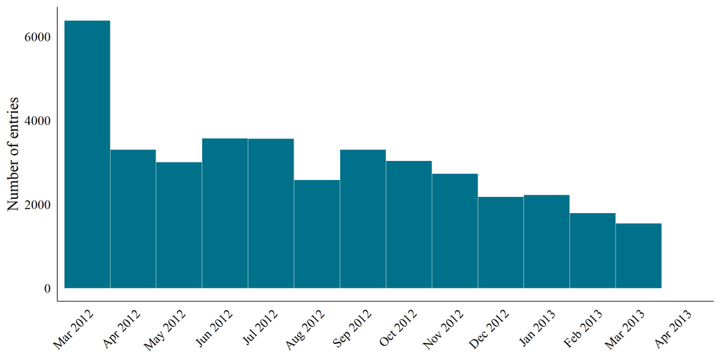

```r
# Entries by calendar month  check for seasonality or data gaps
rdd_sample[, entry_date := as.Date(paste0(
  ref_entry_ym %/% 100L, "-", sprintf("%02d", ref_entry_ym %% 100L), "-01"
))]

ggplot(rdd_sample, aes(x = entry_date)) +
  geom_histogram(bins = uniqueN(rdd_sample$ref_entry_ym),
                 fill = thesis_palette[1], color = "white", linewidth = 0.2) +
  scale_x_date(date_breaks = "1 month", date_labels = "%b %Y") +
  coord_cartesian(xlim = as.Date(c("2012-03-01", "2013-03-31"))) +
  labs(y = "Number of entries", x = NULL) +
  theme_thesis() +
  theme(axis.text.x = element_text(angle = 45, hjust = 1))
```

## 2.3 Characteristics of the first spell of this “unemployed while young” sample

Most people enter at ages 16-20, for a work spell (sanity check), and in a temporary contract.

**Age**

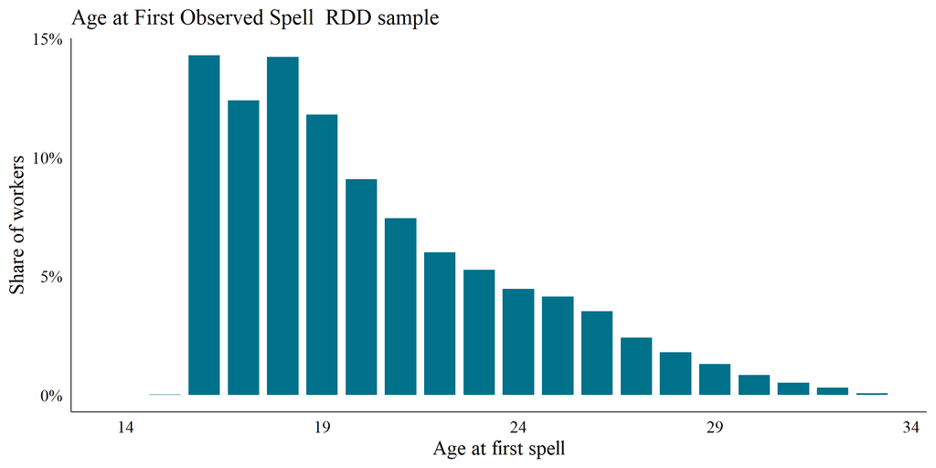

```r
# Join first spell seen date and age to double-check that sample is restricted
# to workers whose panel history starts early enough to trust their lagged state.
# id_first_spell: one row per worker with first_spell_dt, first_spell_age.
.first_spell <- arrow::read_parquet(
  file.path(PATHS$mcvl$clean, "id_first_spell.parquet")
) %>% data.table::as.data.table()

panel_raw[.first_spell, on = "id", `:=`(
  first_spell_dt  = i.first_spell_dt,
  first_spell_age = i.first_spell_age
)]
rm(.first_spell)

# Age at first spell
panel_raw[, .(first_spell_age = first(first_spell_age)), by = id] %>%
  filter(!is.na(first_spell_age), first_spell_age >= 14L, first_spell_age <= 65L) %>%
  ggplot(aes(x = first_spell_age, y = after_stat(prop))) +
  geom_bar(fill = thesis_palette[1], width = 0.8) +
  scale_x_continuous(breaks = seq(14, 65, by = 5)) +
  scale_y_continuous(labels = scales::percent_format()) +
  labs(
    title = "Age at First Observed Spell  RDD sample",
    x = "Age at first spell", y = "Share of workers"
  ) +
  theme_thesis()
```

**Spell type**

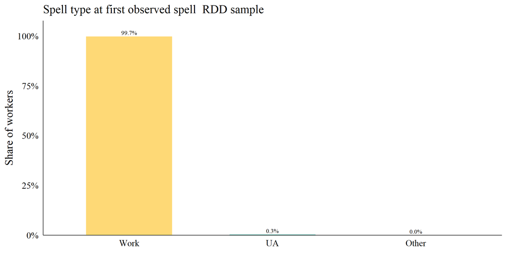

```r
# Load spell type (work vs UA) and contract dummies for the first spell of each
# sample worker, joining from mcvl_spells via first_spell_id.
.first_spell_chars <- arrow::open_dataset(
  file.path(PATHS$mcvl$clean, "mcvl_spells.parquet")
) %>%
  dplyr::select(
    spell_id, spell_work_d, spell_UA_d,
    contract_oe_d, contract_temp_d, contract_train_d, contract_seasonal_d
  ) %>%
  dplyr::collect() %>%
  data.table::as.data.table()

.first_spell_ids <- arrow::read_parquet(
  file.path(PATHS$mcvl$clean, "id_first_spell.parquet"),
  col_select = c("id", "first_spell_id")
) %>% data.table::as.data.table()

.first_spell_ids <- .first_spell_ids[id %in% panel_raw$id]
.first_spell_ids[.first_spell_chars, on = .(first_spell_id = spell_id), `:=`(
  spell_work_d        = i.spell_work_d,
  spell_UA_d          = i.spell_UA_d,
  contract_oe_d       = i.contract_oe_d,
  contract_temp_d     = i.contract_temp_d,
  contract_train_d    = i.contract_train_d,
  contract_seasonal_d = i.contract_seasonal_d
)]
rm(.first_spell_chars)

.first_spell_ids[, spell_type := data.table::fcase(
  spell_UA_d   == 1L, "UA",
  spell_work_d == 1L, "Work",
  default = "Other"
)]

# Spell type breakdown  should be almost entirely "Work"
.first_spell_ids[, .N, by = spell_type][, pct := N / sum(N)] %>%
  ggplot(aes(x = reorder(spell_type, -pct), y = pct, fill = spell_type)) +
  geom_col(width = 0.6) +
  geom_text(aes(label = scales::percent(pct, accuracy = 0.1)), vjust = -0.4, size = 3.5) +
  scale_y_continuous(labels = scales::percent_format(), expand = expansion(mult = c(0, 0.08))) +
  scale_fill_manual(values = thesis_palette[1:3]) +
  labs(title = "Spell type at first observed spell  RDD sample",
       x = NULL, y = "Share of workers") +
  theme_thesis() + theme(legend.position = "none")
```

**Contract type**

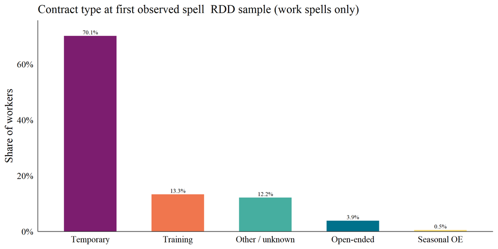

```r
# Contract type at first spell (work spells only).
# "Other / unknown" is large pre-1997 when contract codes were not recorded,
# but should be small for cohorts entering after 2000.
.first_spell_ids[, contract_type := data.table::fcase(
  spell_work_d == 1L & contract_oe_d   == 1L & contract_seasonal_d == 0L, "Open-ended",
  spell_work_d == 1L & contract_seasonal_d == 1L,                          "Seasonal OE",
  spell_work_d == 1L & contract_train_d == 1L,                             "Training",
  spell_work_d == 1L & contract_temp_d  == 1L,                             "Temporary",
  spell_work_d == 1L,                                                       "Other / unknown",
  default = NA_character_
)]

.first_spell_ids[spell_work_d == 1L, .N, by = contract_type][, pct := N / sum(N)] %>%
  ggplot(aes(x = reorder(contract_type, -pct), y = pct, fill = contract_type)) +
  geom_col(width = 0.6) +
  geom_text(aes(label = scales::percent(pct, accuracy = 0.1)), vjust = -0.4, size = 3.5) +
  scale_y_continuous(labels = scales::percent_format(), expand = expansion(mult = c(0, 0.08))) +
  scale_fill_manual(values = thesis_palette[1:5]) +
  labs(title = "Contract type at first observed spell  RDD sample (work spells only)",
       x = NULL, y = "Share of workers") +
  theme_thesis() + theme(legend.position = "none")
```

```r
rm(.first_spell_ids)
```

## 2.4 Contribution caps and wage distribution

The SSC contribution system has monthly minimum and maximum contribution bases that vary by year and contribution group. When a worker’s wage is below the minimum or above the maximum, their contribution base is censored at the respective threshold.

```r
## ---- Censoring summary: share top/bottom coded by year x cont_group --------
cens_summary <- panel_raw[
  cont_base_ym > 0,
  .(
    n            = .N,
    share_top    = mean(f_top_coded,    na.rm = TRUE),
    share_bottom = mean(f_bottom_coded, na.rm = TRUE)
  ),
  by = .(year, cont_group)
][order(year, cont_group)]
```

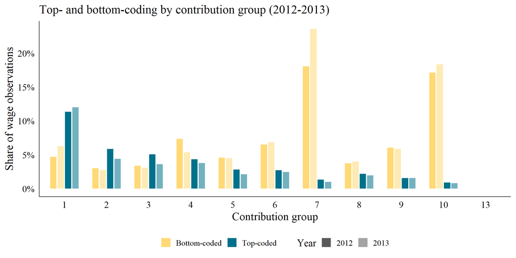

```r
# Reshape long for grouped bar chart  plot only reform years
cens_long <- data.table::melt(
  cens_summary[year %in% c(2012L, 2013L)],
  id.vars      = c("year", "cont_group", "n"),
  measure.vars = c("share_top", "share_bottom"),
  variable.name = "type",
  value.name    = "share"
)
cens_long[, type       := fifelse(type == "share_top", "Top-coded", "Bottom-coded")]
cens_long[, year       := as.factor(year)]
cens_long[, cont_group := as.factor(cont_group)]

ggplot(cens_long, aes(x = cont_group, y = share, fill = type, alpha = year)) +
  geom_col(position = position_dodge(width = 0.7), width = 0.6) +
  scale_y_continuous(labels = scales::percent_format(accuracy = 1)) +
  scale_fill_manual(values = c("Top-coded" = thesis_palette[1], "Bottom-coded" = thesis_palette[3])) +
  scale_alpha_manual(values = c("2012" = 1, "2013" = 0.55)) +
  labs(
    x     = "Contribution group",
    y     = "Share of wage observations",
    fill  = NULL,
    alpha = "Year",
    title = "Top- and bottom-coding by contribution group (2012-2013)"
  ) +
  theme_thesis() +
  theme(legend.position = "bottom")
```

# 3. Empirical strategy: RDD estimation

Donut RDD estimate on the inflow sample of youths entering unemployment in the first year post-reform, using age at unemployment entry as the forcing variable ($z_{i}^{0}$) with cutoff at 31
$$y_{it}=\alpha_{t}+\delta_{t} \cdot \mathbb{1}\left(z_i^0<31\right)+\beta_{t} \cdot\left(z_i^0-31\right) \cdot \mathbb{1}\left(z_i^0<31\right)+\gamma_{t} \cdot\left(z_i^0-31\right) \cdot \mathbb{1}\left(z_i^0 \geq 31\right)+\mu_t X_i^0+\varepsilon_i^t$$
where:

- $y_{it}$ is the outcome for individual $i$ at elapsed duration $t$ since entry into unemployment
- $\alpha_t$ is the constant for the outcomes measured at time $t$
- $\beta_{t} \cdot\left(z_i^0-31\right) \cdot \mathbb{1}\left(z_i^0<31\right)$ is the linear relationship between the forcing variable and the outcome to the left of the cutoff
- $\gamma_{t} \cdot\left(z_i^0-31\right) \cdot \mathbb{1}\left(z_i^0 \geq 31\right)$ is the linear relationship between the forcing variable and the outcome to the right of the cutoff
- $\delta_{t} \cdot \mathbb{1}\left(z_i^0<31\right)$ is a dummy indicator equal to 1 if the individual satisfies the age-eligibility condition. The associated parameter $\delta_{t}$ is the [[ITT|intention to treat]] effect at the cutoff at time $t$
- $X_i^0$ is a vector of control variables included to improve the precision of the estimates: woman, education level (dummies), nationality (Spanish, EU, other), receiving unemployment benefits, any experience between 1 and 4 years before unemployment entry, calendar month of unemployment registration

## 3.1 Check: Counting the number of mass points in the running variable

The canonical RDD assumes a continuous running variable, but age in months is discrete, so we need to check the number of mass points in the running variable. When this number is large, we can still use continuity-based methods for RD analysis after changing the interpretation of the treatment effect of interest and imposing additional assumptions enabling extrapolations (see Cattaneo et al 2024). If this is not the case, a local randomization approach may be better suited.

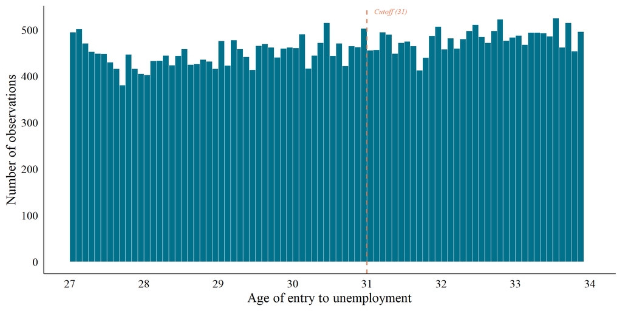

```r
ggplot(rdd_sample[age_frac > RDD_AGE_LO], aes(x = age_frac)) +
  geom_histogram(breaks = seq(RDD_AGE_LO, RDD_AGE_HI, by = 1/12),
                 fill = thesis_palette[1], color = "white", linewidth = 0.2) +
  geom_vline(xintercept = RDD_CUTOFF, linetype = "dashed",
             color = thesis_palette[5], linewidth = 0.8) +
  annotate("text", x = RDD_CUTOFF + 0.1, y = Inf, vjust = 1.5,
           label = "Cutoff (31)", hjust = 0,
           color = thesis_palette[5], size = 3.5, fontface = "italic") +
  scale_x_continuous(breaks = seq(RDD_AGE_LO, RDD_AGE_HI, by = 1),
                     labels = scales::label_number(accuracy = 1)) +
  labs(
    x = "Age of entry to unemployment",
    y = "Number of observations"
  ) +
  theme_thesis()
```

```r
out <- rddensity(rdd_sample$age_centered, bino=FALSE)

summary(out)
```

## 3.2 Check: Falsification tests on predetermined covariates

```r
.rdd_opts <- list(kernel = "triangular", masspoints = "adjust",
                  vce = "hc1", bwselect = "cerrd", p = 1)

.bal_results <- lapply(COV_ALL, function(.v) {
  .dt <- rdd_sample[!is.na(get(.v))]
  .fit <- do.call(rdrobust::rdrobust, c(
    list(y = .dt[[.v]], x = .dt$age_centered),
    .rdd_opts
  ))
  data.table(
    variable = COV_LABELS[.v],
    bw_cer   = round(.fit$bws["h", "left"], 2),
    estimate = round(.fit$coef["Bias-Corrected", ], 2),
    pval     = round(.fit$pv["Robust", ], 3),
    ci_lo    = round(min(.fit$ci["Robust", ]), 2),
    ci_hi    = round(max(.fit$ci["Robust", ]), 2),
    n_obs    = .fit$N_h[1] + .fit$N_h[2]
  )
}) %>% rbindlist()

.bal_results[, stars := data.table::fcase(
  pval < 0.01, "***",
  pval < 0.05, "**",
  pval < 0.10, "*",
  default = ""
)]

kableExtra::kbl(
  .bal_results[, .(variable,
                   bw_cer,
                   est_str  = sprintf("%.2f%s", estimate, stars),
                   ci_str   = sprintf("[%.2f, %.2f]", ci_lo, ci_hi),
                   pval     = sprintf("%.3f", pval),
                   n_obs    = format(n_obs, big.mark = ","))],
  format    = "html",
  booktabs  = TRUE,
  escape    = FALSE,
  align     = c("l", "r", "r", "r", "r", "r"),
  col.names = c("Covariate", "BW (CER)", "RD Estimate", "95% CI", "p-value", "N"),
  caption   = "RD covariate balance at the age-31 cutoff (CER-optimal bandwidth, robust inference)"
) %>%
  kableExtra::kable_styling(
    bootstrap_options = c("striped", "condensed"),
    full_width        = FALSE,
    font_size         = 14
  ) %>%
  kableExtra::pack_rows("Demographics",          1, 4) %>%
  kableExtra::pack_rows("Labour market history", 5, 8) %>%
  kableExtra::pack_rows("Nationality",           9, 11) %>%
  kableExtra::footnote(
    general       = "* p &lt; 0.10, ** p &lt; 0.05, *** p &lt; 0.01. Robust bias-corrected p-values from rdrobust.",
    general_title = "",
    escape        = FALSE
  )
```

RD covariate balance at the age-31 cutoff (CER-optimal bandwidth, robust inference)

| Covariate | BW (CER) | RD Estimate | 95% CI | p-value | N |
| --- | --- | --- | --- | --- | --- |
| **Demographics** |  |  |  |  |  |
| Female | 0.63 | 0.02 | [-0.03, 0.08] | 0.434 | 7,049 |
| Education: primary or less | 0.50 | 0.01 | [-0.04, 0.06] | 0.677 | 5,909 |
| Education: secondary | 0.51 | 0.00 | [-0.06, 0.06] | 0.984 | 5,909 |
| Education: tertiary | 0.65 | -0.00 | [-0.05, 0.04] | 0.886 | 6,830 |
| **Labour market history** |  |  |  |  |  |
| Experience (days) | 0.49 | -10.04 | [-175.77, 155.70] | 0.906 | 5,115 |
| Receiving UA at entry | 0.78 | 0.00 | [-0.05, 0.05] | 0.948 | 8,789 |
| Calendar month of entry | 0.46 | -0.22 | [-0.64, 0.20] | 0.294 | 5,115 |
| Prior UA months | 0.71 | 0.01 | [-0.67, 0.70] | 0.969 | 7,959 |
| **Nationality** |  |  |  |  |  |
| Birth country: Spain | 0.48 | -0.00 | [-0.06, 0.05] | 0.930 | 4,955 |
| Birth country: EU | 0.51 | 0.02* | [-0.00, 0.05] | 0.070 | 5,904 |
| Birth country: Latin America | 0.39 | -0.01 | [-0.06, 0.03] | 0.616 | 4,101 |

* p < 0.10, ** p < 0.05, *** p < 0.01. Robust bias-corrected p-values from rdrobust.

```r
rm(.bal_results, .rdd_opts)
```